# MPDW

Syifa Khairunnisa

2023-09-02

```r
library("forecast")
```

```r
library("graphics")
library("TTR")
library("TSA")
```

*) menginput data

```r
library(rio)
data <- import("https://raw.githubusercontent.com/syifaskn/MPDWPraktikum/main/Data/DataTempSulsel.csv")
data
```

```
##       Time MaxTemp
## 1   Mar-10   30.19
## 2   Apr-10   30.30
## 3   May-10   30.35
## 4   Jun-10   30.28
## 5   Jul-10   30.05
## 6   Aug-10   30.49
## 7   Sep-10   30.88
## 8   Oct-10   31.42
## 9   Nov-10   31.36
## 10  Dec-10   30.48
## 11  Jan-11   29.71
## 12  Feb-11   29.86
## 13  Mar-11   30.32
## 14  Apr-11   30.26
```

[output cut: 116 more lines]

*) eksplorasi data

```r
View(data)
str(data)
```

```
## 'data.frame':    130 obs. of  2 variables:
##  $ Time   : chr  "Mar-10" "Apr-10" "May-10" "Jun-10" ...
##  $ MaxTemp: num  30.2 30.3 30.4 30.3 30.1 ...
```

```r
dim(data)
```

```
## [1] 130   2
```

*) mengubah data agar terbaca sebagai data deret waktu dengan fungsi `ts()`

```r
data.ts <- ts(data$MaxTemp)
```

*) menampilkan ringkasan statistik data

```r
summary(data.ts)
```

```
##    Min. 1st Qu.  Median    Mean 3rd Qu.    Max.
##   29.20   30.12   30.41   30.48   30.80   32.16
```

== Ringkasan statistik yang didapat adalah sebagai berikut: Min = 29.20 Q1 = 30.12 Median = 30.41 Mean = 30.48 Q3 = 30.80 Max = 32.16

*) membuat plot data deret waktu

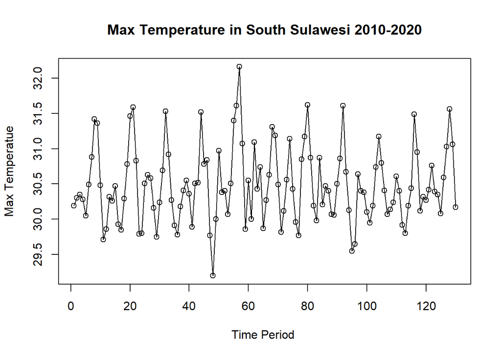

```r
ts.plot(data.ts, xlab="Time Period ", ylab="Max Temperatue",
        main = "Max Temperature in South Sulawesi 2010-2020")
points(data.ts)
```

== Plot sebaran data suhu maksimum terlihat memiliki pola yang musiman (seasonal)

*) menyimpan plot

```r
#menyimpan plot
#dev.copy(png, "eksplorasi.png")
#dev.off()
```

*) pembagian data Pembagian data latih dan data uji dilakukan dengan perbandingan 80% data latih dan 20% data uji.

```r
#membagi data latih dan data uji
training_ma <- data[1:104,]
testing_ma <- data[105:130,]
train_ma.ts <- ts(training_ma$MaxTemp)
test_ma.ts <- ts(testing_ma$MaxTemp)
```

*) eksplorasi data Eksplorasi data dilakukan pada keseluruhan data, data latih serta data uji menggunakan plot data deret waktu.

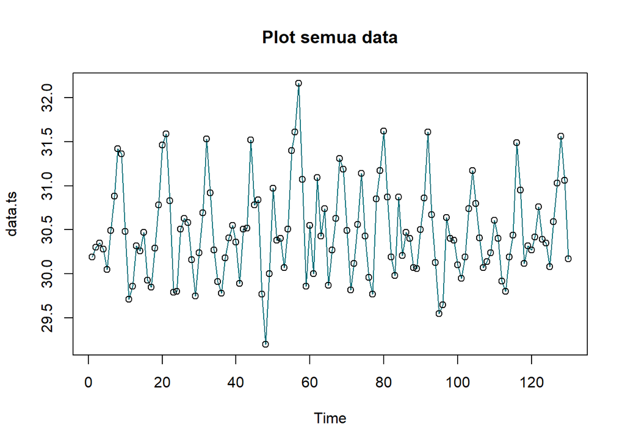

```r
#eksplorasi keseluruhan data
plot(data.ts, col="#006d77",main="Plot semua data")
points(data.ts)
```

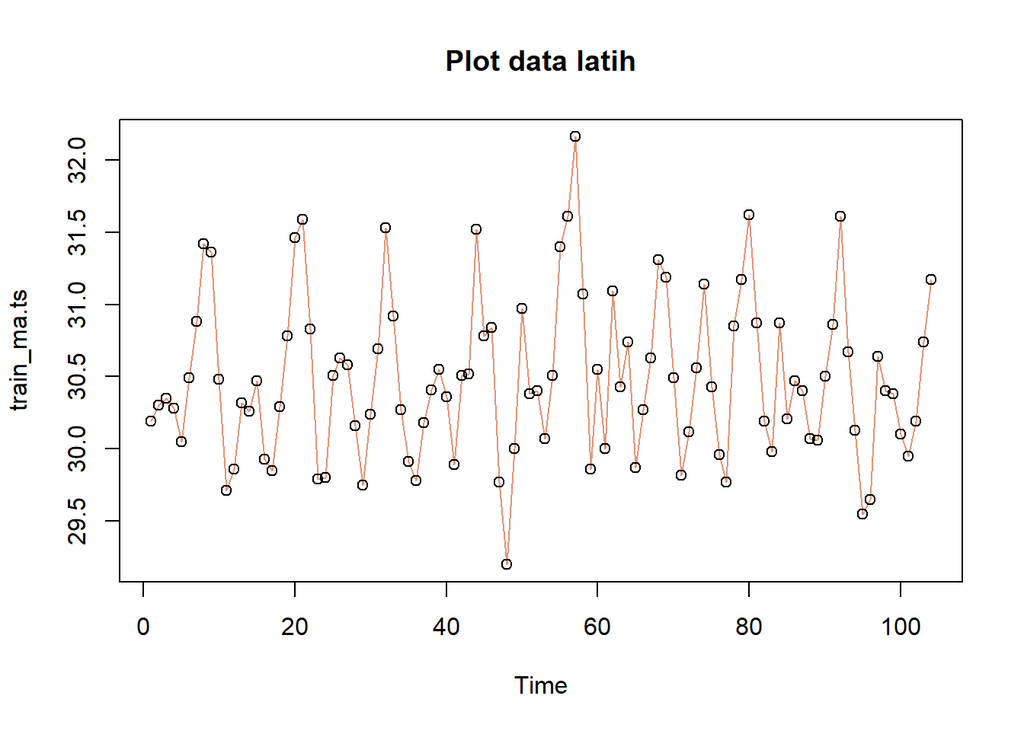

```r
#eksplorasi data latih
plot(train_ma.ts, col="#e29578",main="Plot data latih")
points(train_ma.ts)
```

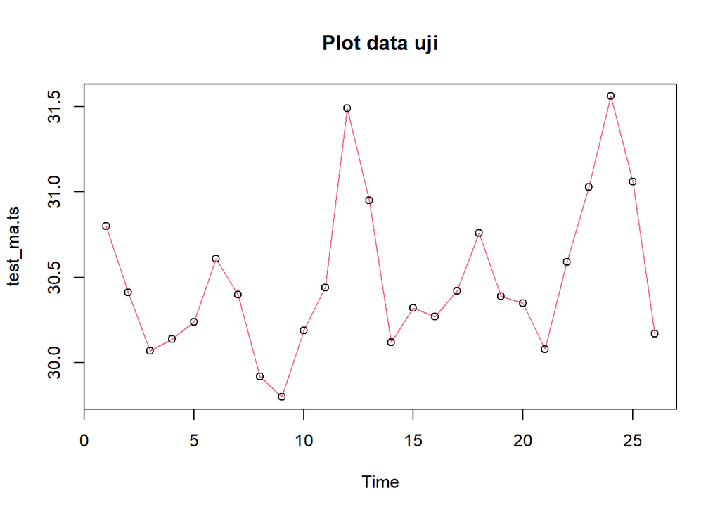

```r
#eksplorasi data uji
plot(test_ma.ts, col="#f26a8d",main="Plot data uji")
points(test_ma.ts)
```

## Pemulusan Data Musiman

Akan dilakukan pemulusan dengan metode winter aditif dan winter multiplikatif karena pola data suhu maksimum yang digunakan berpola data musiman.

```r
#impor kembali data dari github
library(rio)
data1 <- import("https://raw.githubusercontent.com/syifaskn/MPDWPraktikum/main/Data/DataTempSulsel.csv")
data1
```

```
##       Time MaxTemp
## 1   Mar-10   30.19
## 2   Apr-10   30.30
## 3   May-10   30.35
## 4   Jun-10   30.28
## 5   Jul-10   30.05
## 6   Aug-10   30.49
## 7   Sep-10   30.88
## 8   Oct-10   31.42
## 9   Nov-10   31.36
## 10  Dec-10   30.48
## 11  Jan-11   29.71
## 12  Feb-11   29.86
## 13  Mar-11   30.32
## 14  Apr-11   30.26
```

[output cut: 116 more lines]

```r
data1.ts <- ts(data1$MaxTemp)
```

```r
#membagi data menjadi training dan testing
training<-data1[1:104,2]
testing<-data1[105:130,2]
training.ts<-ts(training, frequency = 13)
testing.ts<-ts(testing, frequency = 13)
```

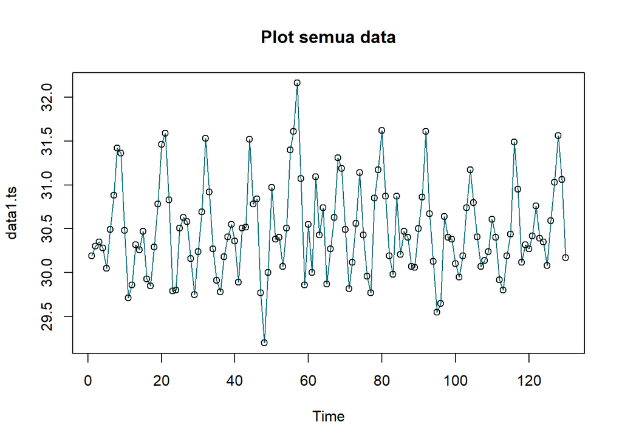

```r
#Membuat plot time series
plot(data1.ts, col="#006d77",main="Plot semua data")
points(data1.ts)
```

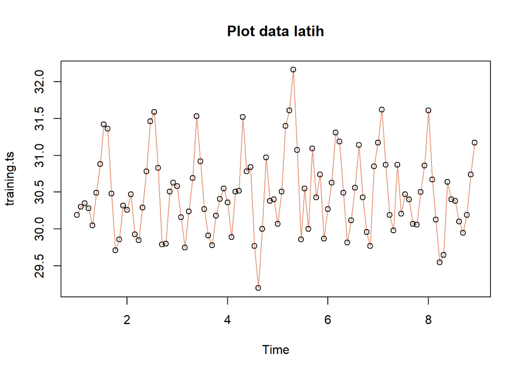

```r
plot(training.ts, col="#e29578",main="Plot data latih")
points(training.ts)
```

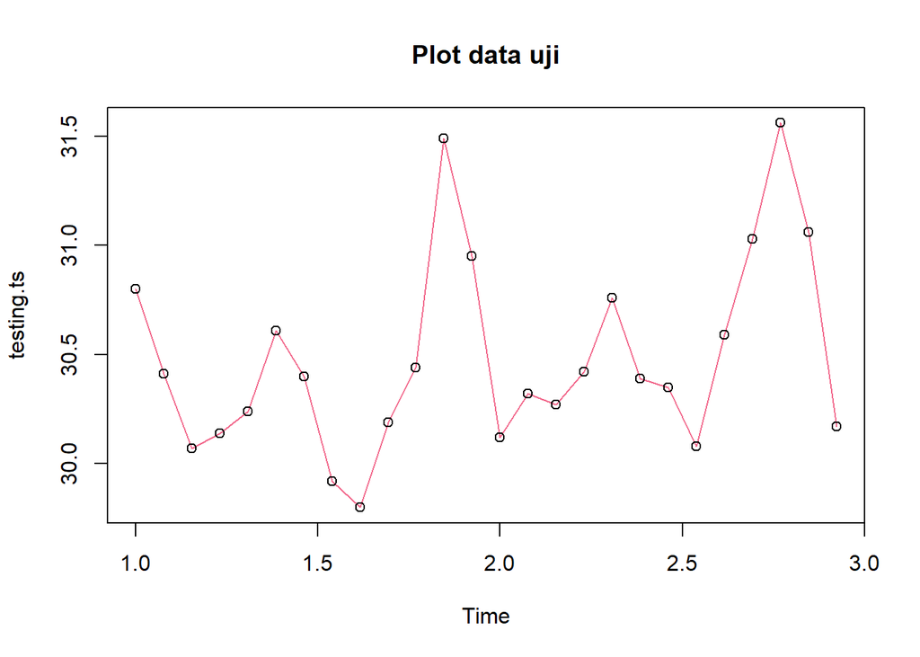

```r
plot(testing.ts, col="#f26a8d",main="Plot data uji")
points(testing.ts)
```

## Pemulusan dengan winter aditif

```r
winter <- HoltWinters(training.ts,alpha=0.1,beta=0.1,gamma=0.1,seasonal = "additive")
winter$fitted
```

```
## Time Series:
## Start = c(2, 1)
## End = c(8, 13)
## Frequency = 13
##              xhat    level         trend       season
## 2.000000 30.19758 30.42993  0.0010786137 -0.233431953
## 2.076923 30.40245 30.43725  0.0017028233 -0.036508876
## 2.153846 29.91235 30.44571  0.0023783530 -0.535739645
## 2.230769 29.88975 30.44985  0.0025548539 -0.562662722
## 2.307692 30.32101 30.44843  0.0021573869 -0.129585799
## 2.384615 30.75975 30.44749  0.0018473235  0.310414201
## 2.461538 31.14921 30.45136  0.0020497932  0.695798817
## 2.538462 31.44929 30.48449  0.0051576719  0.959644970
## 2.615385 31.39685 30.50372  0.0065647244  0.886568047
## 2.692308 30.49337 30.45360  0.0008961937  0.038875740
## 2.769231 29.67997 30.38416 -0.0061375229 -0.698047337
## 2.846154 29.81858 30.39002 -0.0049372617 -0.566508876
## 2.923077 30.32739 30.45423  0.0019769613 -0.128816568
## 3.000000 30.26366 30.48647  0.0050030693 -0.227814066
## 3.076923 30.50084 30.52310  0.0081665108 -0.030429109
## 3.153846 29.96779 30.49719  0.0047580935 -0.534151137
## 3.230769 29.91651 30.48017  0.0025801573 -0.566239925
## 3.307692 30.38853 30.51509  0.0058151010 -0.132376369
## 3.384615 30.87212 30.55106  0.0088297637  0.312236429
## 3.461538 31.36485 30.62567  0.0154085346  0.723769724
## 3.538462 31.57987 30.59660  0.0109600100  0.972308443
## 3.615385 31.30998 30.47657 -0.0021386493  0.835551271
## 3.692308 30.29387 30.33443 -0.0161384845 -0.024427709
## 3.769231 29.55839 30.26691 -0.0212771616 -0.687244987
## 3.846154 29.78845 30.30779 -0.0150610265 -0.504280869
## 3.923077 30.24446 30.35489 -0.0088455359 -0.101581596
## 4.000000 30.17146 30.37660 -0.0057901317 -0.199343092
## 4.076923 30.32465 30.38966 -0.0039047516 -0.061104865
## 4.153846 29.78029 30.34229 -0.0082512443 -0.553752563
## 4.230769 29.86893 30.40701 -0.0009540983 -0.537125432
## 4.307692 30.37147 30.47116  0.0055566027 -0.105244405
## 4.384615 30.98006 30.59157  0.0170418574  0.371445366
## 4.461538 31.28738 30.58861  0.0150412703  0.683733004
## 4.538462 31.42390 30.55891  0.0105674528  0.854420509
## 4.615385 31.10767 30.40409 -0.0059715325  0.709552754
```

[output cut: 41 more lines]

```
## 7.846154 29.97440 30.38372 -0.0187868772 -0.390532137
## 7.923077 30.31888 30.41749 -0.0135308663 -0.085085054
## 8.000000 30.32150 30.45807 -0.0081196186 -0.128450286
## 8.076923 30.61414 30.57880  0.0047653529  0.030575447
## 8.153846 30.37348 30.58915  0.0053239163 -0.220997587
## 8.230769 30.27674 30.57013  0.0028891146 -0.296277570
## 8.307692 30.50336 30.50034 -0.0043782983  0.007390676
## 8.384615 30.61276 30.41063 -0.0129118694  0.215044998
## 8.461538 30.70510 30.40044 -0.0126395079  0.317298982
## 8.538462 30.84482 30.35729 -0.0156905273  0.503220874
## 8.615385 30.67108 30.29512 -0.0203387584  0.396299558
## 8.692308 30.12979 30.21767 -0.0260495656 -0.061831175
## 8.769231 29.68035 30.17364 -0.0278474892 -0.465446144
## 8.846154 29.83078 30.19676 -0.0227509958 -0.343228038
## 8.923077 30.21489 30.26493 -0.0136588228 -0.036383824
```

```r
xhat <- winter$fitted[,2]

winter.opt<- HoltWinters(training.ts, alpha= NULL,  beta = NULL, gamma = NULL, seasonal = "additive")
winter.opt
```

```
## Holt-Winters exponential smoothing with trend and additive seasonal component.
##
## Call:
## HoltWinters(x = training.ts, alpha = NULL, beta = NULL, gamma = NULL,     seasonal = "additive")
##
## Smoothing parameters:
##  alpha: 0.06579863
##  beta : 0
##  gamma: 0.9703806
##
## Coefficients:
##             [,1]
## a   30.480658753
## b    0.001078614
## s1   1.031515316
## s2   0.183769921
## s3  -0.319424525
## s4  -0.862795773
## s5  -0.754423629
## s6   0.232102714
## s7  -0.042155313
## s8  -0.055527948
## s9  -0.312259102
## s10 -0.463519398
## s11 -0.245328573
## s12  0.275937647
## s13  0.678683679
```

```r
winter.opt$fitted
```

```
## Time Series:
## Start = c(2, 1)
## End = c(8, 13)
## Frequency = 13
##              xhat    level       trend      season
## 2.000000 30.19758 30.42993 0.001078614 -0.23343195
## 2.076923 30.39969 30.43512 0.001078614 -0.03650888
## 2.153846 29.90616 30.44082 0.001078614 -0.53573964
## 2.230769 29.88189 30.44347 0.001078614 -0.56266272
## 2.307692 30.31394 30.44245 0.001078614 -0.12958580
## 2.384615 30.75345 30.44195 0.001078614  0.31041420
## 2.461538 31.14166 30.44478 0.001078614  0.69579882
## 2.538462 31.42753 30.46680 0.001078614  0.95964497
## 2.615385 31.36622 30.47857 0.001078614  0.88656805
## 2.692308 30.48432 30.44437 0.001078614  0.03887574
## 2.769231 29.70279 30.39976 0.001078614 -0.69804734
## 2.846154 29.84181 30.40724 0.001078614 -0.56650888
## 2.923077 30.32454 30.45228 0.001078614 -0.12881657
## 3.000000 30.29769 30.47346 0.001078614 -0.17684542
## 3.076923 30.52142 30.49311 0.001078614  0.02723118
## 3.153846 29.95736 30.47041 0.001078614 -0.51412996
## 3.230769 29.86736 30.45785 0.001078614 -0.59156860
## 3.307692 30.33323 30.48344 0.001078614 -0.15129152
## 3.384615 30.84356 30.50800 0.001078614  0.33448544
## 3.461538 31.53971 30.55424 0.001078614  0.98438636
## 3.538462 31.62255 30.51455 0.001078614  1.10693038
## 3.615385 30.82817 30.42663 0.001078614  0.40046746
## 3.692308 29.77782 30.36729 0.001078614 -0.59055076
## 3.769231 29.75967 30.36851 0.001078614 -0.60992736
## 3.846154 30.43756 30.39725 0.001078614  0.03922841
## 3.923077 30.54568 30.39652 0.001078614  0.14808833
## 4.000000 30.47803 30.39788 0.001078614  0.07907481
## 4.076923 30.09186 30.39119 0.001078614 -0.30041033
## 4.153846 29.67796 30.37899 0.001078614 -0.70210796
## 4.230769 30.18214 30.43481 0.001078614 -0.25375503
## 4.307692 30.63133 30.45812 0.001078614  0.17213072
## 4.384615 31.47552 30.51767 0.001078614  0.95676328
## 4.461538 30.89667 30.47299 0.001078614  0.42260222
## 4.538462 30.35222 30.47034 0.001078614 -0.11920198
## 4.615385 30.00230 30.43311 0.001078614 -0.43188552
```

[output cut: 41 more lines]

```
## 7.846154 29.85034 30.48415 0.001078614 -0.63489305
## 7.923077 30.84481 30.52798 0.001078614  0.31575595
## 8.000000 31.10342 30.53006 0.001078614  0.57228210
## 8.076923 31.51858 30.56447 0.001078614  0.95303259
## 8.153846 30.78652 30.50971 0.001078614  0.27573501
## 8.230769 30.14778 30.46759 0.001078614 -0.32089222
## 8.307692 29.92808 30.42934 0.001078614 -0.50233901
## 8.384615 30.69670 30.41212 0.001078614  0.28350059
## 8.461538 30.06181 30.40947 0.001078614 -0.34873762
## 8.538462 30.36233 30.43280 0.001078614 -0.07154992
## 8.615385 30.35525 30.43504 0.001078614 -0.08086287
## 8.692308 30.02362 30.41932 0.001078614 -0.39677930
## 8.769231 29.99000 30.41556 0.001078614 -0.42663098
## 8.846154 30.38492 30.42979 0.001078614 -0.04595474
## 8.923077 30.78484 30.45424 0.001078614  0.32952354
```

```r
xhat.opt <- winter.opt$fitted[,2]
```

*) peramalan

```r
#Forecast
forecast <- predict(winter, n.ahead = 26)
forecast.opt <- predict(winter.opt, n.ahead = 26)
```

*) plot deret waktu

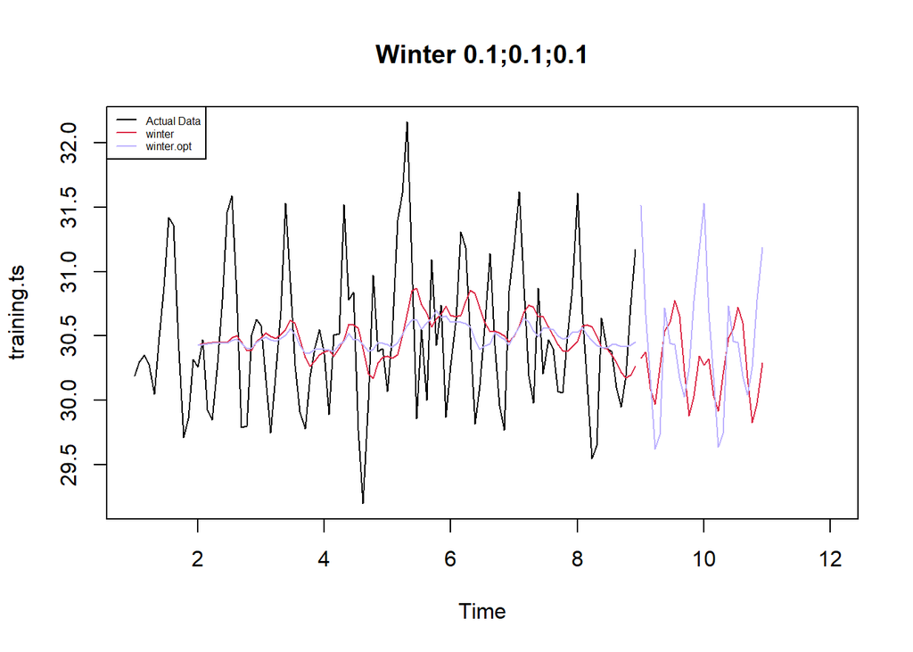

```r
#Plot time series
plot(training.ts,main="Winter 0.1;0.1;0.1",type="l",col="black",
     xlim=c(1,12),pch=12)
lines(xhat,type="l",col="#dd2d4a")
lines(xhat.opt,type="l",col="#bdb2ff")
lines(forecast,type="l",col="#dd2d4a")
lines(forecast.opt,type="l",col="#bdb2ff")
legend("topleft",c("Actual Data",expression(paste(winter)),
                   expression(paste(winter.opt))),cex=0.5,
       col=c("black","#dd2d4a","#bdb2ff"),lty=1)
```

*) akurasi data latih

```r
SSE<-winter$SSE
MSE<-winter$SSE/length(training.ts)
RMSE<-sqrt(MSE)
akurasi <- matrix(c(SSE,MSE,RMSE))
row.names(akurasi)<- c("SSE", "MSE", "RMSE")
colnames(akurasi) <- c("Akurasi")
akurasi
```

```
##         Akurasi
## SSE  49.2611085
## MSE   0.4736645
## RMSE  0.6882329
```

```r
SSE.opt<-winter.opt$SSE
MSE.opt<-winter.opt$SSE/length(training.ts)
RMSE.opt<-sqrt(MSE.opt)
akurasi.opt <- matrix(c(SSE.opt,MSE.opt,RMSE.opt))
row.names(akurasi.opt)<- c("SSE.opt", "MSE.opt", "RMSE.opt")
colnames(akurasi.opt) <- c("Akurasi")
akurasi.opt
```

```
##             Akurasi
## SSE.opt  32.5363602
## MSE.opt   0.3128496
## RMSE.opt  0.5593296
```

```r
akurasi.train = data.frame(Model_Winter = c("Winter","Winter optimal"),
                            Nilai_SSE=c(SSE,SSE.opt),
                            Nilai_MSE=c(MSE,MSE.opt),Nilai_RMSE=c(RMSE,RMSE.opt))
akurasi.train
```

```
##     Model_Winter Nilai_SSE Nilai_MSE Nilai_RMSE
## 1         Winter  49.26111 0.4736645  0.6882329
## 2 Winter optimal  32.53636 0.3128496  0.5593296
```

== Didapatkan nilai SSE, MSE, dan RMSE pada data latih sebagai berikut: SSE Winter Aditif: 49.26111 SSE Winter Aditif Optimal: 32.53636 MSE Winter Aditif: 0.4736645 MSE Winter Aditif Optimal: 0.3128496 RMSE Winter Aditif: 0.6882329 RMSE Winter Aditif Optimal: 0.5593296

*) akurasi data uji

```r
#Akurasi Data Testing
forecast<-data.frame(forecast)
testing.ts<-data.frame(testing.ts)
selisih<-forecast-testing.ts
SSEtesting<-sum(selisih^2)
SSEtesting
```

```
## [1] 10.56835
```

```r
MSEtesting<-SSEtesting/length(testing.ts)
MSEtesting
```

```
## [1] 10.56835
```

```r
forecast.opt<-data.frame(forecast.opt)
selisih.opt<-forecast.opt-testing.ts
SSEtesting.opt<-sum(selisih.opt^2)
SSEtesting.opt
```

```
## [1] 10.1236
```

```r
MSEtesting.opt<-SSEtesting.opt/length(testing.ts)
MSEtesting.opt
```

```
## [1] 10.1236
```

## Pemulusan dengan winter multiplikatif

```r
#Pemulusan dengan winter multiplikatif
winter2 <- HoltWinters(training.ts,alpha=0.2,beta=0.1,gamma=0.3,seasonal = "multiplicative")
winter2$fitted
```

```
## Time Series:
## Start = c(2, 1)
## End = c(8, 13)
## Frequency = 13
##              xhat    level         trend    season
## 2.000000 30.19830 30.42993  0.0010786137 0.9923528
## 2.076923 30.40957 30.44345  0.0023221366 0.9988110
## 2.153846 29.92599 30.45787  0.0035321968 0.9824234
## 2.230769 29.90247 30.46222  0.0036137607 0.9815084
## 2.307692 30.32822 30.45514  0.0025446049 0.9957494
## 2.384615 30.76228 30.45001  0.0017769271 1.0101962
## 2.461538 31.15293 30.45529  0.0021278051 1.0228354
## 2.538462 31.48757 30.51746  0.0081321600 1.0315136
## 2.615385 31.44480 30.54546  0.0101182007 1.0291018
## 2.692308 30.47340 30.43609 -0.0018300176 1.0012861
## 2.769231 29.58740 30.29776 -0.0154805372 0.9770534
## 2.846154 29.75052 30.32580 -0.0111287017 0.9813902
## 2.923077 30.34514 30.46944  0.0043490193 0.9957782
## 3.000000 30.32238 30.53101  0.0100703895 0.9928392
## 3.076923 30.58641 30.59297  0.0152599712 0.9992872
## 3.153846 29.99397 30.52289  0.0067255891 0.9824550
## 3.230769 29.90545 30.47995  0.0017590242 0.9810949
## 3.307692 30.41939 30.54991  0.0085789730 0.9954482
## 3.384615 30.94343 30.61286  0.0140159392 1.0103359
## 3.461538 31.54553 30.74299  0.0256273683 1.0252503
## 3.538462 31.65090 30.64659  0.0134248847 1.0323185
## 3.615385 31.11596 30.39248 -0.0133284423 1.0242539
## 3.692308 29.98253 30.14367 -0.0368765940 0.9958726
## 3.769231 29.38672 30.06612 -0.0409439940 0.9787359
## 3.846154 29.78167 30.18728 -0.0247336475 0.9873724
## 3.923077 30.21779 30.28982 -0.0120062526 0.9980175
## 4.000000 30.18310 30.34439 -0.0053487881 0.9948602
## 4.076923 30.24932 30.37460 -0.0017925866 0.9959343
## 4.153846 29.70198 30.30065 -0.0090083689 0.9805339
## 4.230769 29.96807 30.45645  0.0074727923 0.9837232
## 4.307692 30.52048 30.57614  0.0186940288 0.9975697
## 4.384615 31.29385 30.79522  0.0387331509 1.0149151
## 4.461538 31.38735 30.73270  0.0286072237 1.0203516
## 4.538462 31.32870 30.65402  0.0178786033 1.0214139
## 4.615385 30.79880 30.36669 -0.0126419065 1.0146522
```

[output cut: 41 more lines]

```
## 7.846154 30.08277 30.33989 -0.0211468100 0.9922170
## 7.923077 30.38346 30.40285 -0.0127368478 0.9997812
## 8.000000 30.51967 30.48544 -0.0032039751 1.0012283
## 8.076923 30.91371 30.70003  0.0185757773 1.0063514
## 8.153846 30.78666 30.67017  0.0137322728 1.0033487
## 8.230769 30.43957 30.55301  0.0006429743 0.9962660
## 8.307692 30.33875 30.37507 -0.0172150304 0.9993706
## 8.384615 30.22405 30.22002 -0.0309987121 1.0011601
## 8.461538 30.11480 30.27212 -0.0226892669 0.9955493
## 8.538462 30.38224 30.30672 -0.0169597304 1.0030530
## 8.615385 30.31058 30.28932 -0.0170043715 1.0012642
## 8.692308 30.10863 30.23025 -0.0212107076 0.9966761
## 8.769231 29.89418 30.17721 -0.0243938543 0.9914226
## 8.846154 30.05851 30.21249 -0.0184262974 0.9955106
## 8.923077 30.43338 30.33098 -0.0047350081 1.0035329
```

```r
xhat2 <- winter2$fitted[,2]

winter2.opt<- HoltWinters(training.ts, alpha= NULL,  beta = NULL, gamma = NULL, seasonal = "multiplicative")
winter2.opt$fitted
```

```
## Time Series:
## Start = c(2, 1)
## End = c(8, 13)
## Frequency = 13
##              xhat    level       trend    season
## 2.000000 30.19830 30.42993 0.001078614 0.9923528
## 2.076923 30.40055 30.43566 0.001078614 0.9988110
## 2.153846 29.90793 30.44194 0.001078614 0.9824234
## 2.230769 29.88279 30.44470 0.001078614 0.9815084
## 2.307692 30.31495 30.44328 0.001078614 0.9957494
## 2.384615 30.75397 30.44248 0.001078614 1.0101962
## 2.461538 31.14183 30.44549 0.001078614 1.0228354
## 2.538462 31.43116 30.46983 0.001078614 1.0315136
## 2.615385 31.37063 30.48243 0.001078614 1.0291018
## 2.692308 30.48445 30.44422 0.001078614 1.0012861
## 2.769231 29.69705 30.39342 0.001078614 0.9770534
## 2.846154 29.83766 30.40238 0.001078614 0.9813902
## 2.923077 30.32720 30.45470 0.001078614 0.9957782
## 3.000000 30.30230 30.47852 0.001078614 0.9941831
## 3.076923 30.52813 30.50049 0.001078614 1.0008707
## 3.153846 29.95943 30.47406 0.001078614 0.9830777
## 3.230769 29.86741 30.45921 0.001078614 0.9805361
## 3.307692 30.33762 30.48870 0.001078614 0.9950094
## 3.384615 30.85207 30.51627 0.001078614 1.0109681
## 3.461538 31.55481 30.56750 0.001078614 1.0322628
## 3.538462 31.62917 30.52259 0.001078614 1.0362181
## 3.615385 30.82430 30.42556 0.001078614 1.0130694
## 3.692308 29.77299 30.35914 0.001078614 0.9806578
## 3.769231 29.75795 30.36075 0.001078614 0.9801106
## 3.846154 30.43529 30.39404 0.001078614 1.0013216
## 3.923077 30.53861 30.39323 0.001078614 1.0047476
## 4.000000 30.46928 30.39516 0.001078614 1.0024030
## 4.076923 30.08419 30.38808 0.001078614 0.9899646
## 4.153846 29.67298 30.37449 0.001078614 0.9768701
## 4.230769 30.18409 30.43965 0.001078614 0.9915691
## 4.307692 30.63272 30.46607 0.001078614 1.0054345
## 4.384615 31.48052 30.53315 0.001078614 1.0309910
## 4.461538 30.89560 30.48341 0.001078614 1.0134859
## 4.538462 30.35610 30.48038 0.001078614 0.9958872
## 4.615385 30.00873 30.43745 0.001078614 0.9858800
```

[output cut: 41 more lines]

```
## 7.846154 29.84879 30.49504 0.001078614 0.9787736
## 7.923077 30.84916 30.54588 0.001078614 1.0098930
## 8.000000 31.09664 30.54776 0.001078614 1.0179319
## 8.076923 31.50676 30.58656 0.001078614 1.0300490
## 8.153846 30.76930 30.52688 0.001078614 1.0079055
## 8.230769 30.13448 30.48052 0.001078614 0.9886125
## 8.307692 29.91879 30.43738 0.001078614 0.9829274
## 8.384615 30.68215 30.41800 0.001078614 1.0086483
## 8.461538 30.04870 30.41595 0.001078614 0.9878905
## 8.538462 30.35425 30.44363 0.001078614 0.9970288
## 8.615385 30.35084 30.44664 0.001078614 0.9968181
## 8.692308 30.02230 30.42890 0.001078614 0.9866027
## 8.769231 29.98941 30.42450 0.001078614 0.9856645
## 8.846154 30.38162 30.44080 0.001078614 0.9980208
## 8.923077 30.78101 30.46873 0.001078614 1.0102135
```

```r
xhat2.opt <- winter2.opt$fitted[,2]
```

```r
#peramalan (forecast)
forecast2 <- predict(winter2, n.ahead = 26)
forecast2.opt <- predict(winter2.opt, n.ahead = 26)
```

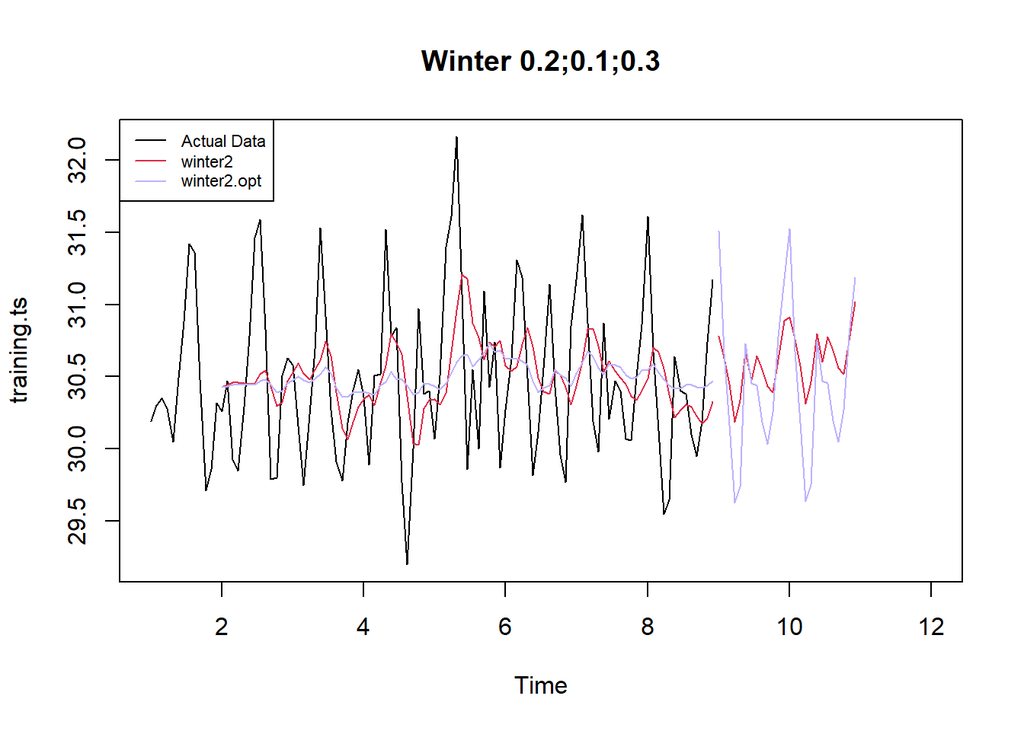

```r
#Plot time series
plot(training.ts,main="Winter 0.2;0.1;0.3",type="l",col="black",
     xlim=c(1,12),pch=12)
lines(xhat2,type="l",col="#dd2d4a")
lines(xhat2.opt,type="l",col="#bdb2ff")
lines(forecast2,type="l",col="#dd2d4a")
lines(forecast2.opt,type="l",col="#bdb2ff")
legend("topleft",c("Actual Data",expression(paste(winter2)),
                   expression(paste(winter2.opt))),cex=0.7,
       col=c("black","#dd2d4a","#bdb2ff"),lty=1)
```

```r
#Akurasi data training
SSE2<-winter2$SSE
MSE2<-winter2$SSE/length(training.ts)
RMSE2<-sqrt(MSE2)
akurasi <- matrix(c(SSE2,MSE2,RMSE2))
row.names(akurasi)<- c("SSE2", "MSE2", "RMSE2")
colnames(akurasi) <- c("Akurasi lamda=0.2")
akurasi
```

```
##       Akurasi lamda=0.2
## SSE2         41.8427792
## MSE2          0.4023344
## RMSE2         0.6342984
```

```r
SSE2.opt<-winter2.opt$SSE
MSE2.opt<-winter2.opt$SSE/length(training.ts)
RMSE2.opt<-sqrt(MSE2.opt)
akurasi1.opt <- matrix(c(SSE2.opt,MSE2.opt,RMSE2.opt))
row.names(akurasi1.opt)<- c("SSE2.opt", "MSE2.opt", "RMSE2.opt")
colnames(akurasi1.opt) <- c("Akurasi")
akurasi1.opt
```

```
##              Akurasi
## SSE2.opt  32.5542275
## MSE2.opt   0.3130214
## RMSE2.opt  0.5594832
```

```r
akurasi2.train = data.frame(Model_Winter = c("Winter 1","winter2 optimal"),
                            Nilai_SSE=c(SSE2,SSE2.opt),
                            Nilai_MSE=c(MSE2,MSE2.opt),Nilai_RMSE=c(RMSE2,RMSE2.opt))
akurasi2.train
```

```
##      Model_Winter Nilai_SSE Nilai_MSE Nilai_RMSE
## 1        Winter 1  41.84278 0.4023344  0.6342984
## 2 winter2 optimal  32.55423 0.3130214  0.5594832
```

== Didapatkan nilai SSE, MSE, dan RMSE pada data latih sebagai berikut: SSE Winter Multiplikatif: 41.84278  
SSE Winter Multiplikatif Optimal: 32.55423  
MSE Winter Multiplikatif: 0.4023344 MSE Winter Multiplikatif Optimal: 0.3130214 RMSE Winter Multiplikatif: 0.6342984  
RMSE Winter Multiplikatif Optimal: 0.5594832

```r
#Akurasi Data Testing
forecast2<-data.frame(forecast2)
testing.ts<-data.frame(testing.ts)
selisih2<-forecast2-testing.ts
SSEtesting2<-sum(selisih2^2)
SSEtesting2
```

```
## [1] 5.971838
```

```r
MSEtesting2<-SSEtesting2/length(testing.ts)
MSEtesting2
```

```
## [1] 5.971838
```

```r
forecast2.opt<-data.frame(forecast2.opt)
selisih2.opt<-forecast2.opt-testing.ts
SSEtesting2.opt<-sum(selisih2.opt^2)
SSEtesting.opt
```

```
## [1] 10.1236
```

```r
MSEtesting2.opt<-SSEtesting2.opt/length(testing.ts)
MSEtesting2.opt
```

```
## [1] 10.04696
```